# Installation

You can install the development version of ggVolcano as bellow:

```r
# install.packages("devtools")
# devtools::install_github("pigudogzyy/PDtools")
```

# ggVolcano

The goal of ggVolcano is to help users make a beautiful volcano map more easily, including general volcano plot(ggvolcano), gradient color volcano plot(gradual_volcano) and GO term volcano plot(term_volcano).

Use function ggvolcano to make a general volcano plot.

### basic use

- Make sure you have a DEG result data containing information on differentially expressed genes (including GeneName, Log2FC, pValue, FDR).
- If your data don’t have a column named ‘regulate’, you can use the `add_regulate` function to add.
- Use function `ggvolcano` to make a general volcano plot. You can use `?ggvolcano` to see the parameters of the function.

```r
library(PDtools)
## basic example code
# load the data
data(deg_data)
```

we can have a rough view about this data

```r
head(deg_data)
```

```
##                 row   baseMean log2FoldChange     lfcSE       stat       pvalue
## GCR1           GCR1  7201.5782       2.244064 0.2004959  11.192564 4.434241e-29
## OPI10         OPI10  1009.4171      -2.257454 0.2096469 -10.767889 4.880607e-27
## AGA2           AGA2   249.1173       3.829474 0.3623263  10.569132 4.143136e-26
## FIM1_1376 FIM1_1376  5237.5035       2.550409 0.2560379   9.961059 2.256459e-23
## HMG1           HMG1 10838.1037       2.214300 0.2229065   9.933763 2.968371e-23
## FIM1_3918 FIM1_3918  2456.8070       2.288243 0.2356228   9.711467 2.694309e-22
##                   padj
## GCR1      2.153711e-25
## OPI10     1.185255e-23
## AGA2      6.707736e-23
## FIM1_1376 2.739905e-20
## HMG1      2.883475e-20
## FIM1_3918 2.181043e-19
```

the important parameter of this deg data include

- row
- log2FlodChange
- pvalue
- padj

```r
# use the function -- add_regulate to add a regulate column
# to the DEG result data.
library(PDtools)
data <- add_regulate(deg_data, log2FC_name = "log2FoldChange",
                     fdr_name = "padj",log2FC = 1, fdr = 0.05)
table(data$regulate)
```

```
##
##   Down Normal     Up
##    487   4136    234
```

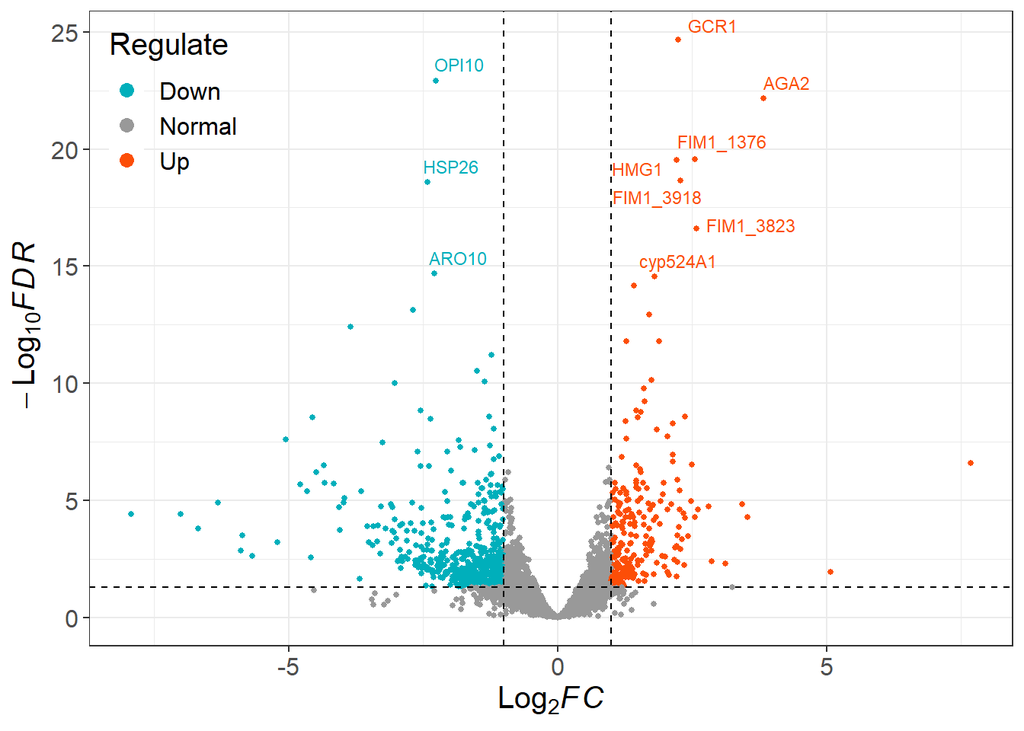

```r
# plot
ggvolcano(data, x = "log2FoldChange", y = "padj",
          label = "row", label_number = 10, output = FALSE)
```

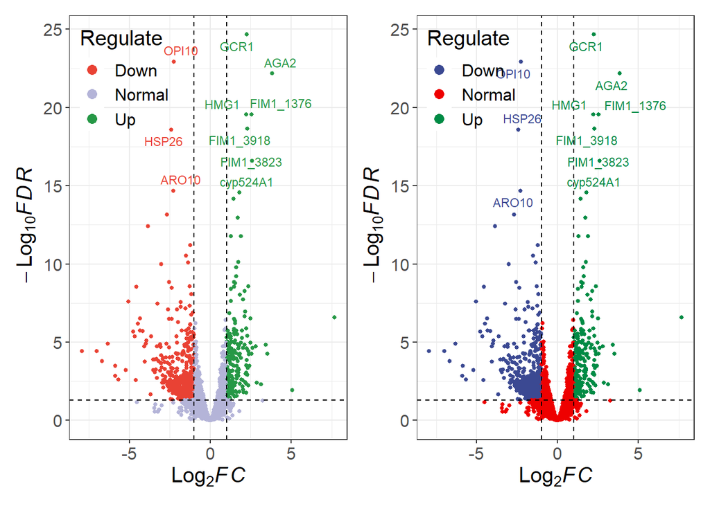

```r
# Change the fill and color manually:
p1 <- ggvolcano(data, x = "log2FoldChange", y = "padj",
          fills = c("#e94234","#b4b4d8","#269846"),
          colors = c("#e94234","#b4b4d8","#269846"),
          label = "row", label_number = 10, output = FALSE)

p2 <- ggvolcano(data, x = "log2FoldChange", y = "padj",
          label = "row", label_number = 10, output = FALSE)+
  ggsci::scale_color_aaas()+
  ggsci::scale_fill_aaas()
library(patchwork)
p1|p2
```

## Use function `gradual_volcano` to make a gradient color volcano plot.

### basic use

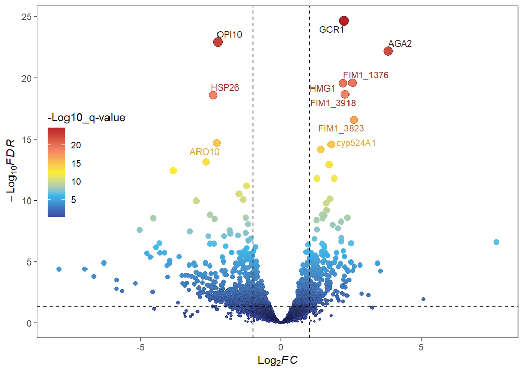

```r
# plot
gradual_volcano(deg_data, x = "log2FoldChange", y = "padj",
                label = "row", label_number = 10, output = FALSE)
```

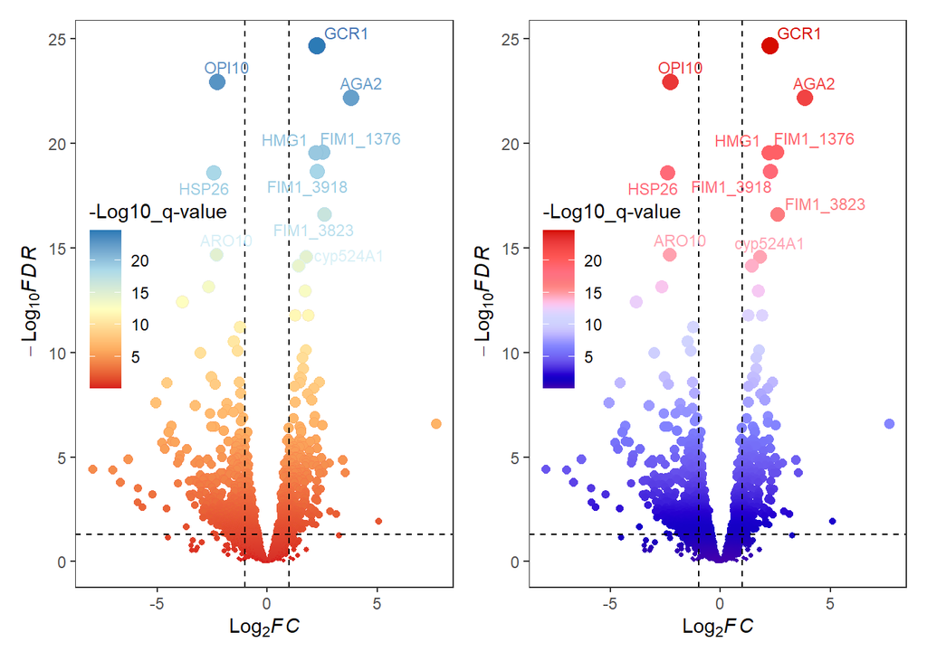

```r
library(RColorBrewer)

# Change the fill and color manually:
p1 <- gradual_volcano(data, x = "log2FoldChange", y = "padj",
          fills = brewer.pal(5, "RdYlBu"),
          colors = brewer.pal(8, "RdYlBu"),
          label = "row", label_number = 10, output = FALSE)

p2 <- gradual_volcano(data, x = "log2FoldChange", y = "padj",
          label = "row", label_number = 10, output = FALSE)+
  ggsci::scale_color_gsea()+
  ggsci::scale_fill_gsea()
library(patchwork)
p1|p2
```

```r
data("term_data")
head(term_data)
```

```
##   Gene.names   term
## 1       TDP1 myelin
## 2    YDR387C myelin
## 3      MAM33 myelin
## 4       BAR1 myelin
## 5       IQG1 myelin
## 6       AIM3 myelin
```

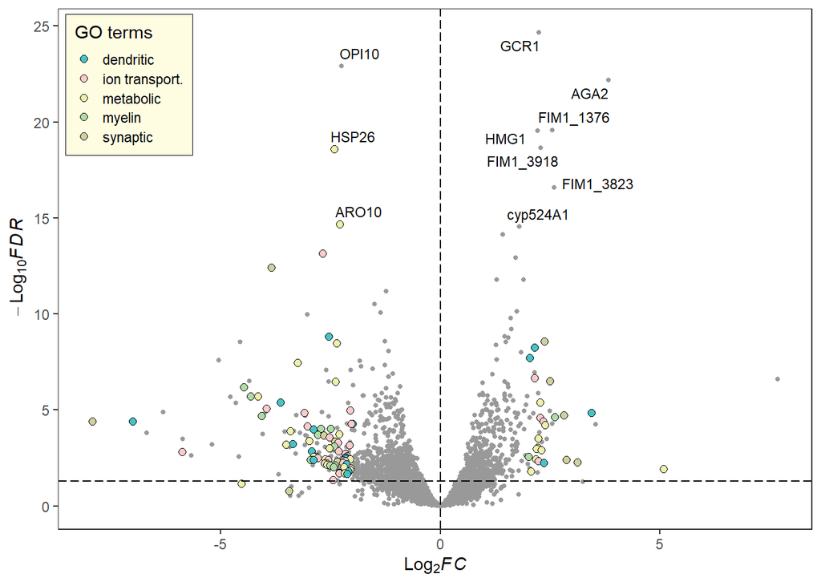

```r
# plot
term_volcano(deg_data, term_data,
             x = "log2FoldChange", y = "padj",
             label = "row", label_number = 10, output = FALSE)
```

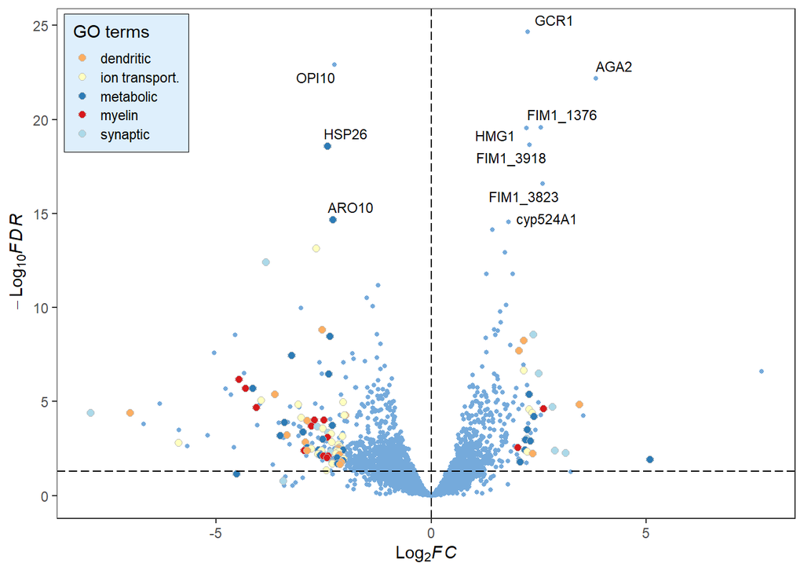

```r
library(RColorBrewer)

# Change the fill and color manually:
deg_point_fill <- brewer.pal(5, "RdYlBu")
names(deg_point_fill) <- unique(term_data$term)

term_volcano(data, term_data,
             x = "log2FoldChange", y = "padj",
             normal_point_color = "#75aadb",
             deg_point_fill = deg_point_fill,
             deg_point_color = "grey",
             legend_background_fill = "#deeffc",
             label = "row", label_number = 10, output = FALSE)
```